# Telcom Data Analysis

# FB: KNIT CHECK POINT: worked!

FB: Let’s look at the make up of senior customers

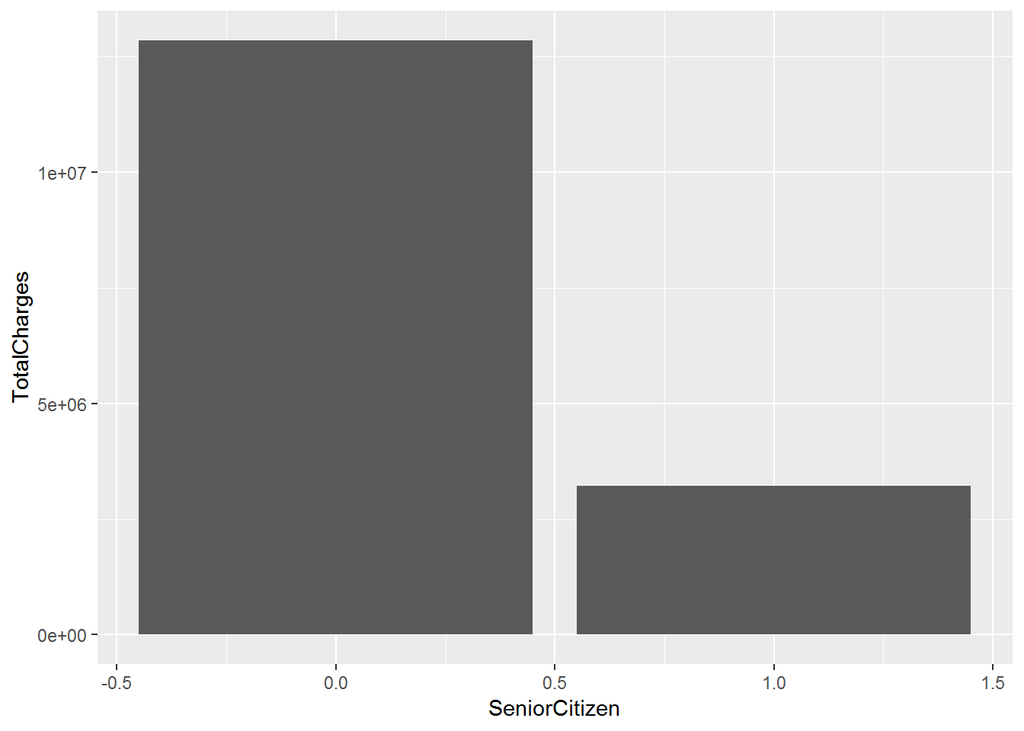

```r
mytelcom %>%
 ggplot(aes(x=SeniorCitizen, y=TotalCharges)) +
    geom_bar(stat="identity")
```

# FB: Weird x-axis and same old y-axix issue remains.

# FB: class (mytelcom$SeniorCitizen) … returns numeric

# FB: Let’s try as a factor

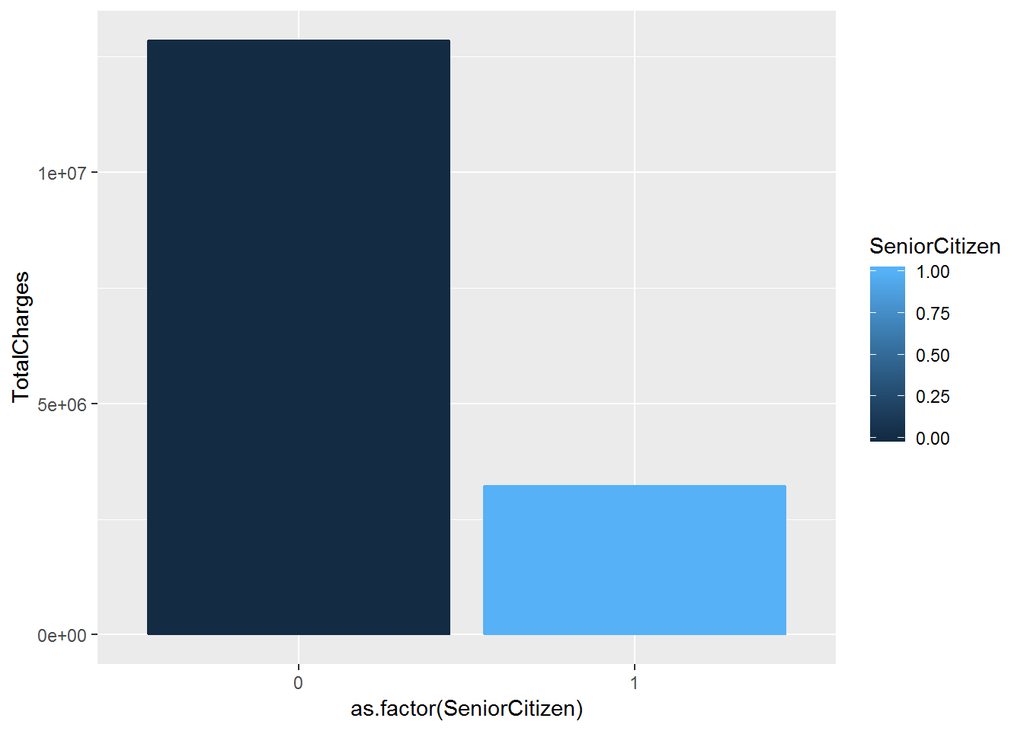

```r
mytelcom %>%
 ggplot(aes(x=as.factor(SeniorCitizen), y=TotalCharges, color=SeniorCitizen)) +
    geom_bar(stat="identity", fill="white")
```

FB: Better! But, we don’t know what 0 or 1 maps to. FB: I looked deeper and will assume 0 = not a senior.

# FB: KNIT CHECK POINT: worked!

# FB: Let’s look at possible correlations…need to guess at this since I can’t runn the “plot” cmd on such a large dataset.

# FB: 1st, check som point graphs between numeric variables:

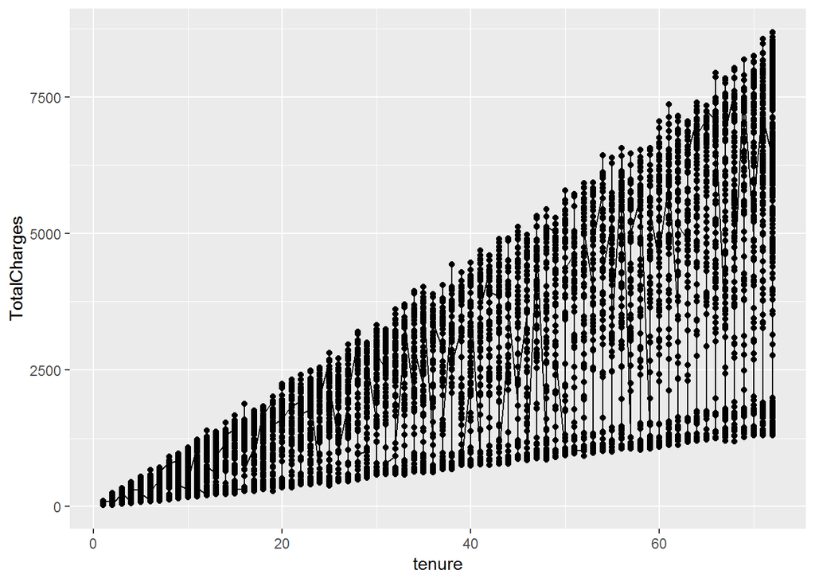

```r
mytelcom %>%
 ggplot(aes(x=tenure, y=TotalCharges)) +
    geom_point() +
    geom_line()
```

FB: Yes, this makes sense to me…ALL TotalCharges increase as time (tenure) increases. This is a nice and “tidy” envelope.

FB: Now look at MonthlyCharges:

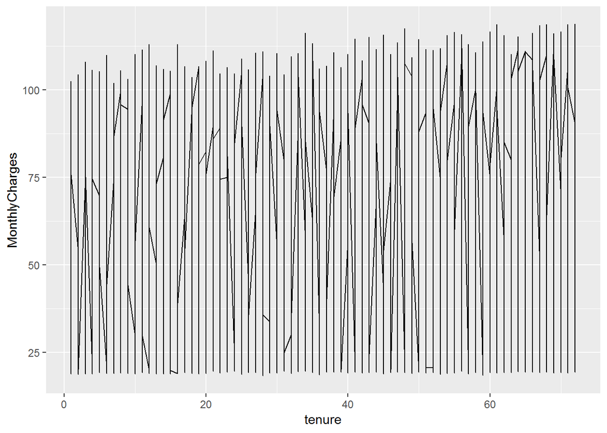

```r
mytelcom %>%
 ggplot(aes(x=tenure, y=MonthlyCharges)) +
    geom_line()
```

# FB: To much to absorb! But, MonthlyCharges go up and down, and not always to zero (Churn) customer.

# FB: I see that this company offers both “DSL”" (over phone wires), and “Fiber optic” and the class for InternetService is “character”

# FB: What percentages are DSL and Fiber?

```r
mytelcom %>%
  group_by(InternetService) %>%
  summarize(n = n()) %>%
  mutate(pct = n/ sum(n))
```

```
## # A tibble: 3 x 3
##   InternetService     n   pct
##   <chr>           <int> <dbl>
## 1 DSL              2416 0.344
## 2 Fiber optic      3096 0.440
## 3 No               1520 0.216
```

# FB: Summary of InternetService is that this company is mainly in Fiber, followed by DSL, and 21% have not InternetService (but may have other services such as phone). There is nothing like satelite service here.

# FB: What is the customer gender makeup?

# FB: What percentages are DSL and Fiber?

```r
mytelcom %>%
  group_by(gender) %>%
  summarize(n = n()) %>%
  mutate(pct = n/ sum(n))
```

```
## # A tibble: 2 x 3
##   gender     n   pct
##   <chr>  <int> <dbl>
## 1 Female  3483 0.495
## 2 Male    3549 0.505
```

# FB: This rounds out to 50/50 by gender.

# FB: Is Churn biased by gender?

```r
mytelcom %>%
  group_by(gender) %>%
  group_by(Churn) %>%
  summarize(n = n()) %>%
  mutate(pct = n/ sum(n))
```

```
## # A tibble: 2 x 3
##   Churn     n   pct
##   <chr> <int> <dbl>
## 1 No     5163 0.734
## 2 Yes    1869 0.266
```

# FB - Lets plot it instead…

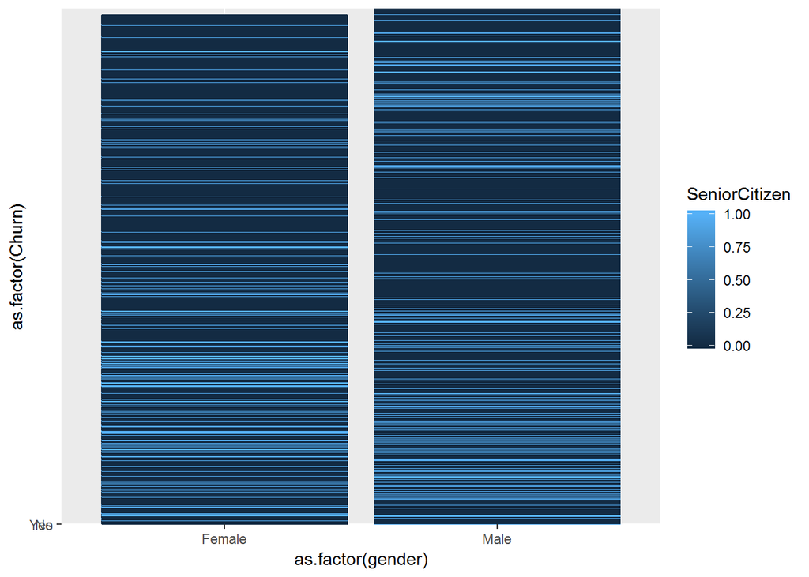

```r
mytelcom %>%
  group_by (Churn) %>%
 ggplot(aes(x=as.factor(gender), y=as.factor(Churn), color=SeniorCitizen)) +
    geom_histogram(stat="identity", fill="white")
```

# FB: Wow, weirdest bar chart ever? What’s going on here?

# FB: While I’d like to work on this particular dataset further…

Have I done enough for Assignment05 yet? I’ll move onto 06 for Monday’s class.